# Overview of the minixcali package

Baptiste Auguié

2021-01-02

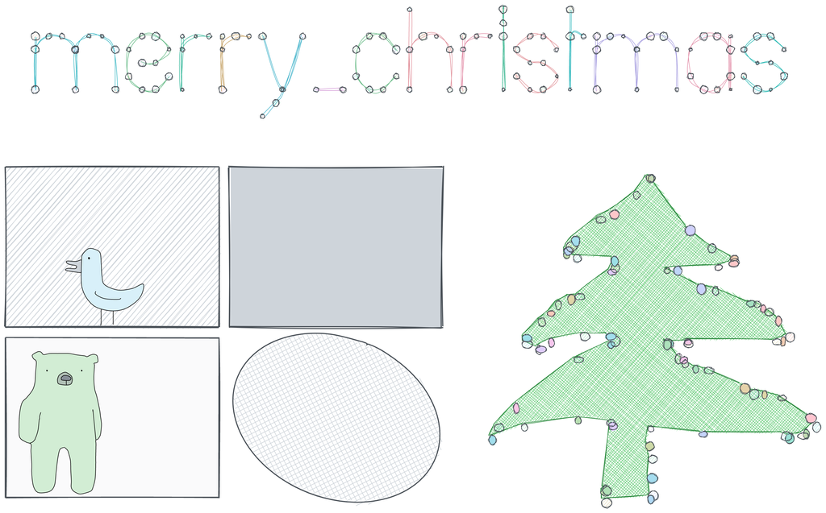

## The Excalidraw format

Excalidraw can import and export its scenes in json; the format consists of 5 top-level entries, of which the important one is `elements`, which is an array containing the description of each basic glyph in the scene.

```
{
"type": "excalidraw",
"version": 2,
"source": "https://excalidraw.com",
"elements": [
{
"type": "rectangle",
"fillStyle": "solid",
[...]
"groupIds": []
},
{
"type": "rectangle",
"fillStyle": "solid",
[...]
"groupIds": []
}
],
"appState": {
"viewBackgroundColor": "#ffffff",
"gridSize": null
}
}
```

Note that there doesn’t appear to be a device size / viewport / viewbox. I’m also unsure what the units are; looking at the SVG export it seems to be the same default “px”, i.e. 1/96th of an inch, i.e. about a quarter of a mm.

## Elements

- “type”: “rectangle” or “ellipse” or “draw” or “text”. There’s also “line” and “arrow” but the difference is only relevant for the user interface.

Each glyph is assigned some identification,

- “seed”: 233882977 # to generate unique random variations
- “id”: “3HjMtdwNS5YZdRqmv3BFM” # unique ID, e.g. md5 hash of object
- “groupIds”: [] # array of strings indicating glyph groupings
- “boundElementIds” — ids of (linear) elements that are bound to this element for connected glyphs

Finally the following attributes for collaboration,

- “version”: integer that is sequentially incremented on each change. Currently used to reconcile elements during collaboration or when saving to server.
- “versionNonce”: random integer that is regenerated on each change. Used for deterministic reconciliation of updates during collaboration, in case the versions are identical.
- “isDeleted”: flag to keep track of deletes in collaboration

## Creating a simple scene

`minixcali` defines a very basic R6 class `ExcaliDocument` which initialises the 5 top-level nodes of the json object. Two methods are defined,

- `$add`, to add glyphs to the `elements` field
- `$export`, to save the object to a json file (via `jsonlite`)

The `$add` method simply appends glyph(s) to the list of elements. Each glyph needs to be a well-formed list of attributes, such as

```r
list(type = "rectangle",
     x = -407.242554, y = 0,
     width = 44, height = 44,
     angle = 0,
     strokeColor = "#495057",
     backgroundColor = "#ced4da",
     fillStyle = "hachure",
     strokeWidth = 1,
     strokeStyle = "solid",
     roughness = 1L,
     opacity = 100L,
     strokeSharpness = "sharp",
     isDeleted = FALSE,
     groupIds = list(),
     boundElementIds = NA,
     id = "2732dc14872d3709d5978813d7bf550c",
     seed = 1260353516L,
     version = 32L,
     versionNonce = 784119031L)
```

`minixcali` provides 4 functions (`xkd_rectangle()`, `xkd_ellipse()`, `xkd_draw()`, `xkd_text()`) to generate such lists from the set of default parameters.

```r
str(xkd_text(text = "new label",
             strokeColor = "#555555"))
```

```
## List of 27
##  $ type           : chr "text"
##  $ x              : num 0
##  $ y              : num 0
##  $ width          : num 100
##  $ height         : num 100
##  $ angle          : num 0
##  $ strokeColor    : chr "#555555"
##  $ backgroundColor: chr "transparent"
##  $ fillStyle      : chr "solid"
##  $ strokeWidth    : int 2
##  $ strokeStyle    : chr "solid"
##  $ roughness      : int 0
##  $ opacity        : int 100
##  $ groupIds       : list()
##  $ strokeSharpness: chr "sharp"
##  $ isDeleted      : logi FALSE
##  $ boundElementIds: NULL
##  $ text           : chr "new label"
##  $ fontSize       : int 36
##  $ fontFamily     : int 1
##  $ textAlign      : chr "left"
##  $ verticalAlign  : chr "top"
##  $ baseline       : int 32
##  $ version        : num 1
##  $ versionNonce   : num 12345
##  $ id             : chr "f70196a525eb9d64e4d5ac49e89f34db"
##  $ seed           : int 514051984
```

To create multiple shapes at once it can be useful to create a list or data.frame of attributes, and use `purrr` functions to iterate over them,

```r
a <- tribble(~x, ~y, ~width, ~height, ~roughness, ~backgroundColor,
             -300 ,   -80,   300,    300, 0, "#ced4da",
             10 ,   -80,   300,    300, 1, "#ced4da",
             320 ,   -80,   300,    300, 2, "#ced4da")

a$strokeWidth <- 2

d <- Excali_doc()
invoke(d$add, pmap(a, minixcali::xkd_rectangle))
str(d$elements, max.level = 1)
```

```
## List of 3
##  $ :List of 21
##  $ :List of 21
##  $ :List of 21
```

We can the export the full tree to json and open it in Excalidraw,

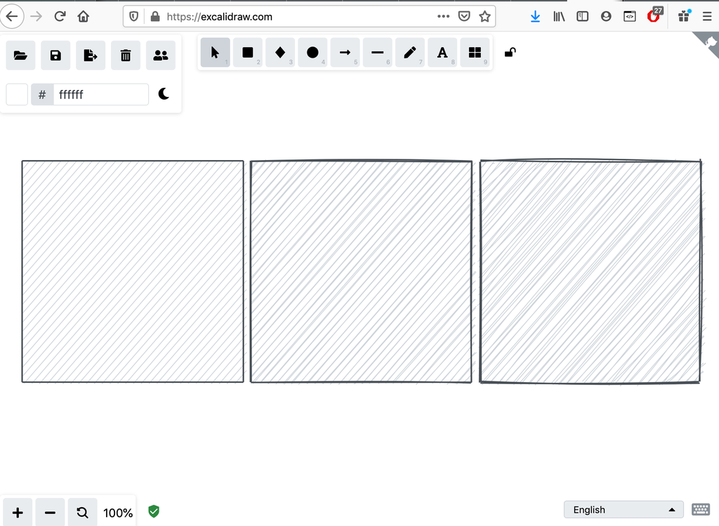

```r
d$export(file='testing.json')
```

The drawing may be edited at https://excalidraw.com/#json=5181621544157184,h3q8WL5-2HPBFjkjQeu5RA

## Lines

`line`, `arrow` and `draw` elements (the difference is in the interaction with online tools; there’s none from the JSON perspective) require a `points` attribute that encodes (x,y) node coordinates in an array structure.

```r
str(.kevin) # stored coords in the package under data/
```

```
## List of 6
##  $ :List of 7
##   ..$ x              : num -3.14
##   ..$ y              : num 128
##   ..$ width          : num 29.5
##   ..$ height         : num 22.8
##   ..$ backgroundColor: chr "#ced4da"
##   ..$ strokeColor    : chr "#000000"
##   ..$ points         : num [1:11, 1:2] -11.4 -39 -36.2 -22.2 -20.4 ...
##  $ :List of 7
##   ..$ x              : num -13.2
##   ..$ y              : num 92.9
##   ..$ width          : num 115
##   ..$ height         : num 115
##   ..$ backgroundColor: chr "#d8f0f9"
##   ..$ strokeColor    : chr "#000000"
##   ..$ points         : num [1:18, 1:2] 0 0.26 18.2 45.32 73.92 ...
##  $ :List of 7
##   ..$ x              : num -0.922
##   ..$ y              : num 104
##   ..$ width          : num 2.6
##   ..$ height         : num 2.83
##   ..$ backgroundColor: chr "#000000"
##   ..$ strokeColor    : chr "#000000"
##   ..$ points         : num [1:8, 1:2] 0 0.694 2.256 2.604 2.083 ...
##  $ :List of 7
##   ..$ x              : num 41.5
##   ..$ y              : num 187
##   ..$ width          : num 1.45
##   ..$ height         : num 29.6
##   ..$ backgroundColor: chr "#ced4da"
##   ..$ strokeColor    : chr "#000000"
##   ..$ points         : num [1:3, 1:2] -18.6 -18.6 -20 0 26.8 ...
##  $ :List of 7
##   ..$ x              : num 45.6
##   ..$ y              : num 189
##   ..$ width          : int 0
##   ..$ height         : num 26
##   ..$ backgroundColor: chr "#ced4da"
##   ..$ strokeColor    : chr "#000000"
##   ..$ points         : num [1:2, 1:2] 0 0 0 26
##  $ :List of 7
##   ..$ x              : num 13.1
##   ..$ y              : num 153
##   ..$ width          : num 47
##   ..$ height         : num 15.2
##   ..$ backgroundColor: chr "#ced4da"
##   ..$ strokeColor    : chr "#000000"
##   ..$ points         : num [1:5, 1:2] 0 0 15.9 41.9 47 ...
```

```r
d <- Excali_doc()

for (l in .kevin) {
  call <- c(l,
    list(
      groupIds = list(list("kevin")),
      strokeSharpness = "round",
      fillStyle = "solid",
      strokeWidth = 1L,
      roughness = 0L
    )
  )

  shape <- invoke(xkd_draw, call)
  d$add(shape)

}

d$export('drawing.json')
```

Drawing at https://excalidraw.com/#json=5903088405708800,72BcP2Ry6NHWbHEUpidg9w

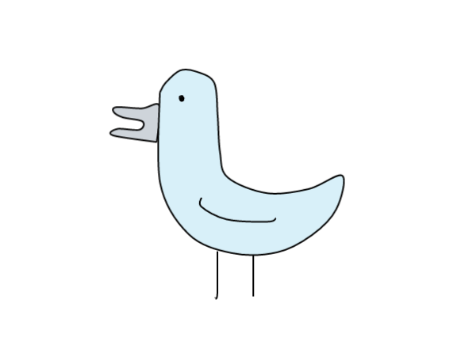